# temperature_tunes

## Introduction

The quest for understanding climate change has led to the accumulation of extensive temperature data over the years. One common format for storing such large-scale environmental data is the NetCDF (Network Common Data Form) file format. The R programming language, known for its robust data analysis and visualization capabilities, provides a suite of packages and functions to handle, analyze, and visualize NetCDF data. In this blog post, we’ll walk you through a project that involves processing and visualizing temperature data stored in a NetCDF file using R. I will visualize the data both as an animated lineplots and as maps.

Data was sourced from [National Centers for Environmental Information](https://www.ncei.noaa.gov/access/metadata/landing-page/bin/iso?id=gov.noaa.ncdc:C00332)

The code for this analysis can be found on the project [GitHub](https://github.com/SamMajumder/Data_Viz_Ecology_Sonification_Projects/tree/main/Temperature_Tunes)

## PART 1: Processing and visualizing using an animated lineplot

### Phase 1:**Setup and data acquisition**

Here’s our general approach:

- Set scientific notation off for better readability of large numbers.
- Loaded necessary libraries for working with NetCDF data and visualizations.
- Checked for and created necessary directories to organize our data and outputs.
- Set a high timeout limit to ensure successful data download, especially for large files.
- Defined the data URL and the destination file path.
- Downloaded the NetCDF file containing temperature data.

```r
options(scipen=999)

packages <- list("ncdf4","here","tidyverse","raster","progress","ggplot2",
                 "gganimate","transformr","purrr")



lapply(packages, require,character.only = T)
```

```
here() starts at C:/Users/samba/Documents/Temperature_tunes
```

[output not shown]

[output not shown]

```r
# Check if "Datasets" and "Figures" folder exists, if not, create it

# List of directories to create
dirs_to_create <- c("Datasets", "Figures")

# Loop through the directories and create them if they don't exist
for (dir_name in dirs_to_create) {
  dir_path <- here(dir_name)

  if (!dir.exists(dir_path)) {
    dir.create(dir_path)
  }
}




###################################
##### Download data ###
########


#### setting a high timeout limit ## setting it to 10 minutes

options(timeout=600)


# Define the URL
url <- "https://www.ncei.noaa.gov/data/nclimgrid-monthly/access/nclimgrid_tavg.nc"


# Define the destination file path using here()
dest_file <- here("Datasets",
                  "nclimgrid_tavg.nc")


# Download the file
download.file(url, dest_file, mode = "wb")
```

### Phase 2: Data reading and processing

```r
# Read the NetCDF file
temp_data <- brick(here("Datasets","nclimgrid_tavg.nc"))

# Subset the raster brick to include only layers 781 through the end
temp_data_subset <- subset(temp_data, 781:nlayers(temp_data))

# Calculate yearly averages
num_years <- ceiling(nlayers(temp_data_subset) / 12)
pb <- progress_bar$new(total = num_years, format = "[:bar] :percent Year :current/:total (:eta/:elapsed)")

yearly_avg_list <- map(1:num_years, function(i) {
  start_layer <- (i-1)*12 + 1
  if (i == num_years) {
    end_layer <- nlayers(temp_data_subset)
  } else {
    end_layer <- start_layer + 11
  }
  yearly_layers <- temp_data_subset[[start_layer:end_layer]]
  yearly_avg <- mean(getValues(yearly_layers), na.rm = TRUE)
  pb$tick()
  return(yearly_avg)
})

# Convert the list of averages to a data frame
df <- data.frame(Year = 1960:2023,
                 Average_Temperature = unlist(yearly_avg_list))
```

### **Phase 3: Visualizing the Trends**

- Utilized **`ggplot2`** and **`gganimate`** packages to create an animated plot showcasing the temperature trend over the years.
- The **`transition_reveal`** function was used to reveal the temperature trend year by year, creating a compelling visualization.
- The animated plot was saved as a GIF file, making it easy to share and view.

```r
# Create an animated plot to visualize the average temperature trend
animated_plot <- df %>%
  ggplot(aes(x = Year, y = Average_Temperature)) +
  geom_line(aes(color = Average_Temperature),size = 1) +
  geom_point(aes(color = Average_Temperature),size = 2) +
  scale_color_viridis_c(direction = -1) +
  labs(title = 'Average Temperature in the Contiguous US',
       x = 'Year',
       y = 'Average Temperature') +
  theme_bw() +
  theme(text = element_text(size = 10)) +
  transition_reveal(Year)
# Save the animated plot as a GIF
gganimate::anim_save("Figures/Temperature_change.gif",animation = animated_plot)
```

```
`geom_line()`: Each group consists of only one observation.
ℹ Do you need to adjust the group aesthetic?
`geom_line()`: Each group consists of only one observation.
ℹ Do you need to adjust the group aesthetic?
```

Final product looks something like this

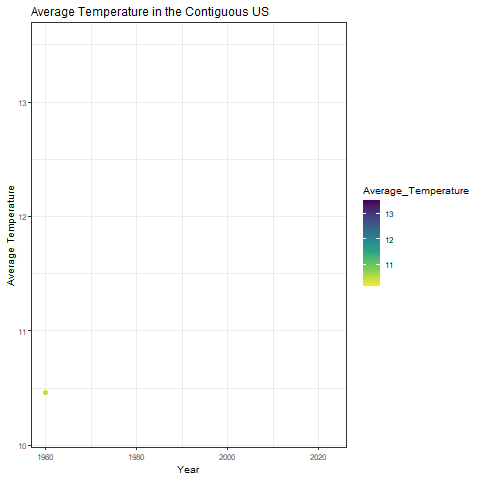

## PART 2: Mapping the data across the contiguous US

### Yearly Average Calculation:

- A loop iterates through the data, calculating the yearly average temperature for each cell.
- A progress bar is initialized and updated during each iteration to provide feedback on the computation progress.

```r
# Calculate yearly averages
num_years <- ceiling(nlayers(temp_data_subset) / 12)

yearly_avg_list <- list()

# Initialize a progress bar
pb <- progress_bar$new(total = num_years, format = "[:bar] :percent :elapsedfull")

for (i in 1:num_years) {
  start_layer <- (i-1)*12 + 1

  # If it's the last iteration and there are less than 12 layers left, adjust the end_layer
  if (i == num_years) {
    end_layer <- nlayers(temp_data_subset)
  } else {
    end_layer <- start_layer + 11
  }

  yearly_layers <- temp_data_subset[[start_layer:end_layer]]

  # Calculate the mean for each cell across the selected layers
  yearly_avg <- raster::mean(yearly_layers)

  yearly_avg_list[[i]] <- yearly_avg

  # Update the progress bar
  pb$tick()
}
```

### Data Transformation:

- The calculated yearly averages are first stacked together, then converted to a dataframe for easier manipulation.

```r
yearly_avg_stack <- stack(yearly_avg_list)
yearly_avg_df <- raster::as.data.frame(yearly_avg_stack, xy=TRUE)
```

### Column Renaming and Reshaping:

- The dataframe is restructured and renamed to facilitate further analysis and visualization.

```r
old_names <- colnames(yearly_avg_df)

Years <- c(1960:2023)

new_names <- c("Long","Lat",Years)


yearly_avg_df <- yearly_avg_df %>%
                  rename_at(vars(old_names), ~ new_names)
### Long format ###

# Reshape the data to long format using pivot_longer

columns_to_change <- colnames(yearly_avg_df %>% dplyr::select(`1960`:`2023`))


yearly_avg_long <- pivot_longer(yearly_avg_df,
                                cols = columns_to_change,
                                names_to = "Year",
                                values_to = "Temperature")
# Designated folder for saving plots
output_folder <- here("Figures")
```

### Visualization and Export:

- A function **`create_plot_for_year`** is defined to create and save a plot for each year.
- A new progress bar is initialized to track the progress of plot generation and saving.
- Finally, the script iterates through all the years, generating and saving a plot for each.

```r
# function to save plots in the designated folder

create_plot_for_year <- function(year) {
  data_for_year <- yearly_avg_long %>% filter(Year == year)

  p <- ggplot(data_for_year, aes(x = Long, y = Lat, fill = Temperature)) +
    geom_tile() +
    scale_fill_viridis_c(direction = -1) +
    theme_minimal() +
    labs(title = paste("Average Temperature for", year),
         x = "Longitude",
         y = "Latitude",
         fill = "Temperature")

  # Save the plot in the designated folder
  filename <- file.path(output_folder, paste0("plot_", year, ".png"))
  ggsave(filename, p, width = 10, height = 6)

  # Update the progress bar
  setTxtProgressBar(pb, which(unique(yearly_avg_long$Year) == year))

  # Print the completion statement
  print(paste("Completed plot for the year", year, "and saved in", filename))

  return(filename)
}

# Initialize the progress bar for exporting plots
total_years <- length(unique(yearly_avg_long$Year))


pb <- txtProgressBar(min = 0, max = total_years, style = 3)
# Generate and save plots for each year
saved_files <- lapply(unique(yearly_avg_long$Year), create_plot_for_year)
# Close the progress bar after all plots are exported
close(pb)
```

After creating the plots, I decided to create a timelapse gif. For this I used a free online tool from [Canva](https://www.canva.com/create/gif-maker/)

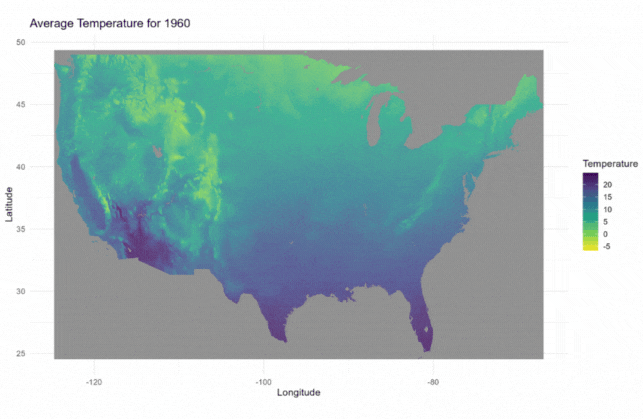